# Bank Marketing Report

#### Random Forest

The second model we will develop is Random Forest. Random Forest requires factor target variable in classification problem, so we need to transform it.

```r
train$y_fact = factor(train$y, levels = c(0,1))
val$y_fact = factor(val$y, levels = c(0,1))
```

First, let’s build initial Random Forest model using all explanatory variables, 100 trees and default number of sampled variables used for a split (squared root of the number of all variables). It is crucial to take into account proper classes weights.

```r
set.seed(8)
rf_initial = randomForest(y_fact ~ ., data = train[,-4], ntree=100, classwt = c(1, 7.87), do.trace = T)
```

```
## ntree      OOB      1      2
##     1:  33.95% 31.49% 53.56%
##     2:  34.77% 32.62% 51.84%
##     3:  33.05% 30.42% 53.86%
##     4:  31.91% 29.06% 54.31%
##     5:  31.41% 28.40% 55.13%
##     6:  30.01% 26.87% 54.71%
##     7:  29.18% 25.96% 54.54%
##     8:  28.44% 25.07% 54.97%
##     9:  27.86% 24.48% 54.51%
##    10:  27.32% 23.81% 55.06%
##    11:  27.71% 24.26% 54.95%
##    12:  27.09% 23.64% 54.32%
##    13:  26.49% 23.15% 52.91%
##    14:  25.96% 22.43% 53.85%
```

[output cut: 86 more lines]

```r
rf_initial
```

```
##
## Call:
##  randomForest(formula = y_fact ~ ., data = train[, -4], ntree = 100,      classwt = c(1, 7.87), do.trace = T)
##                Type of random forest: classification
##                      Number of trees: 100
## No. of variables tried at each split: 6
##
##         OOB estimate of  error rate: 19.86%
## Confusion matrix:
##       0    1 class.error
## 0 25234 4796   0.1597070
## 1  1923 1879   0.5057864
```

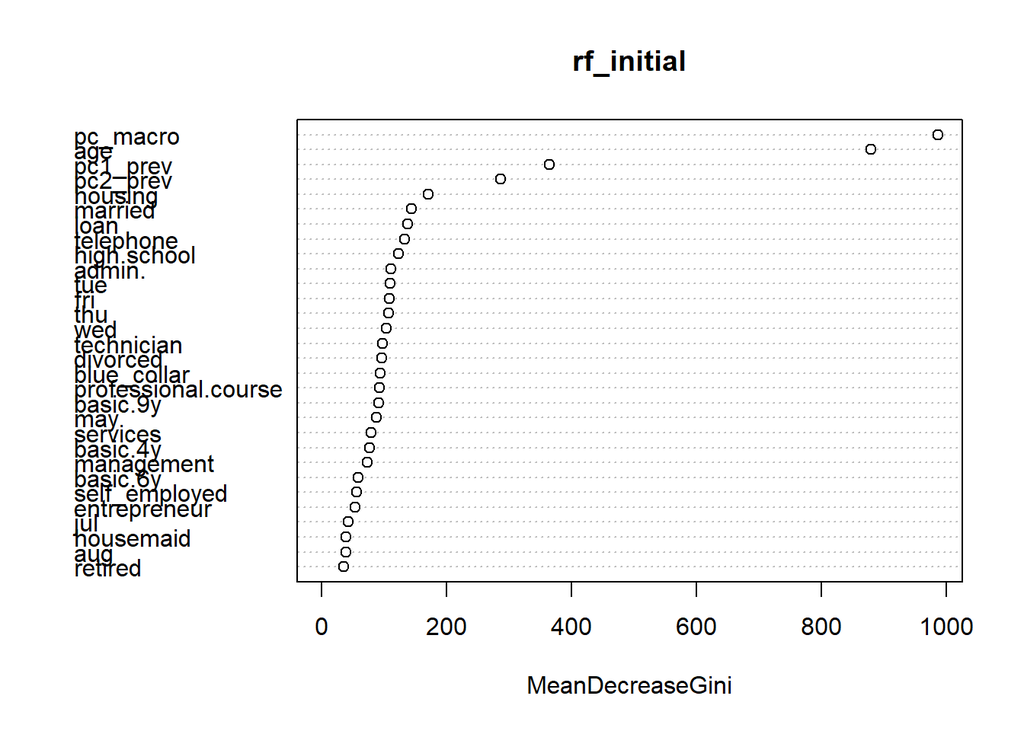

```r
varImpPlot(rf_initial)
```

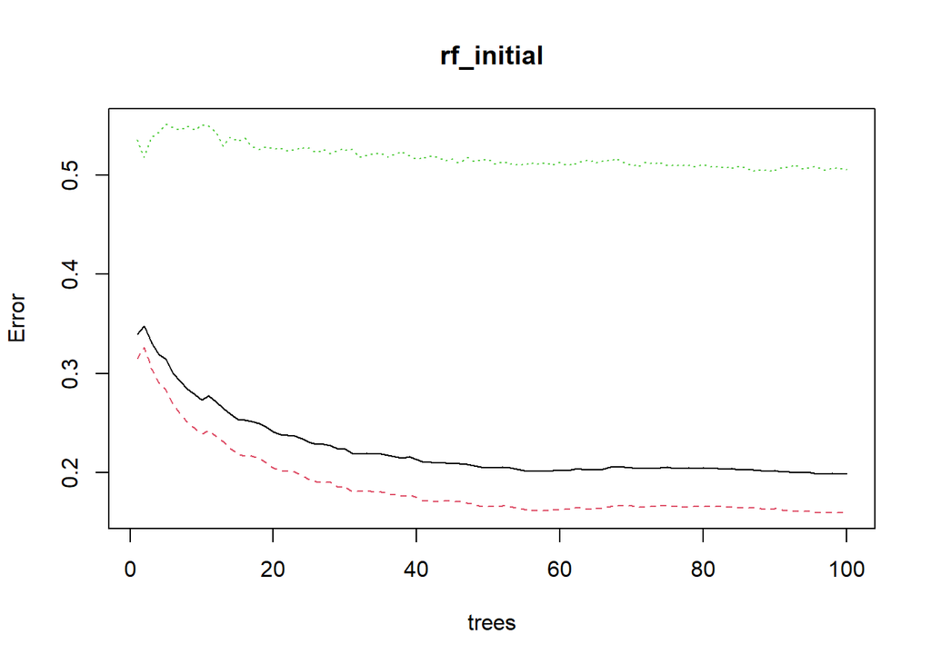

```r
plot(rf_initial)
```

We can see that with an increase of number of trees above few dozens, performance does not improve substantially. Next, we will choose optimal number of variables selected for splits. Optimality is, again, defined by cost-based performance.

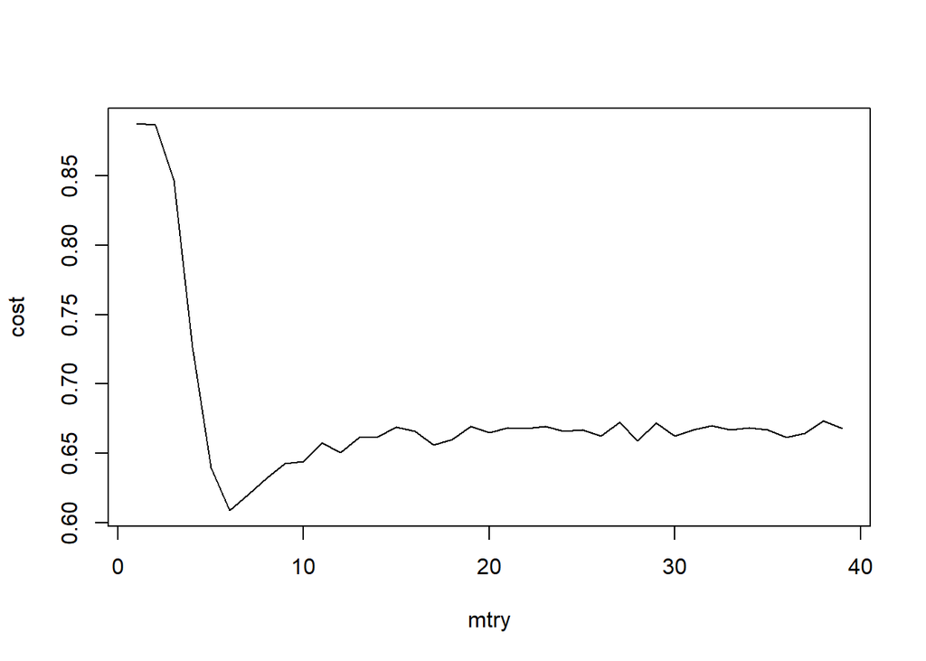

```r
set.seed(8)
mtry = c(1:ncol(train[,-c(4,41)]))
cost=c()
for(i in 1:length(mtry)){
  #print(i)
  cost[i] = sum(prop.table(randomForest(y_fact ~ ., data = train[,-4], ntree = 40, mtry = mtry[i], classwt = c(1, 7.87))$confusion[,-3])*COST_MATRIX)
}
plot(mtry, cost, type="l")
```

```r
rf_optimal = randomForest(y_fact ~ ., data = train[,-4], ntree = 100, mtry = 7, classwt = c(1, 7.87), do.trace = T)
```

```
## ntree      OOB      1      2
##     1:  30.93% 28.10% 54.07%
##     2:  29.03% 25.76% 55.62%
##     3:  27.17% 23.61% 55.87%
##     4:  26.70% 22.86% 57.42%
##     5:  25.62% 21.53% 58.08%
##     6:  25.63% 21.39% 59.15%
##     7:  24.92% 20.73% 58.02%
##     8:  24.40% 20.05% 58.79%
##     9:  23.72% 19.25% 58.93%
##    10:  23.26% 18.79% 58.61%
##    11:  22.91% 18.36% 58.81%
##    12:  22.38% 17.73% 59.09%
##    13:  21.65% 16.86% 59.44%
##    14:  21.31% 16.45% 59.70%
```

[output cut: 86 more lines]

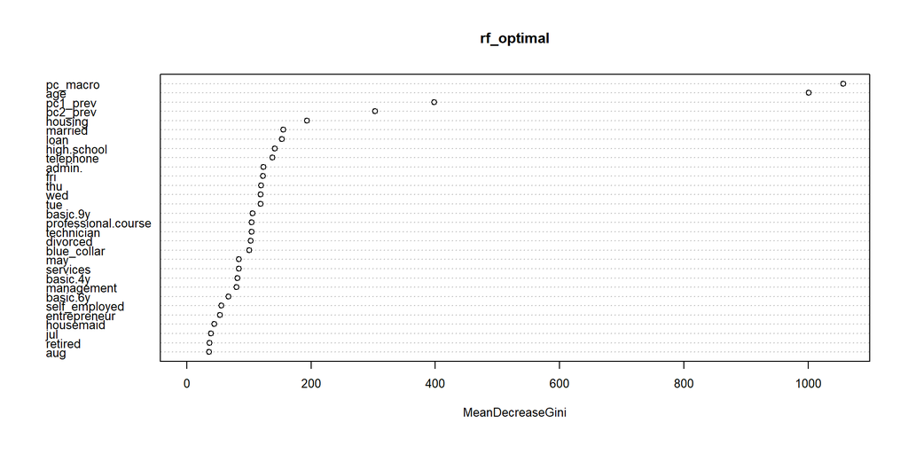

```r
varImpPlot(rf_optimal, cex = 0.8)
```

Random Forest model suggests that macroeconomic conditions are the most important. Surprisingly, age turned out to be almost as much important, although it was omitted in Logistic Regression. Probably age impact is not linear and hence Random Forest was able to capture this dependence, while Logistic Regression was not. It is consistent with findings from EDA part, where we investigated that young people just after studies and the oldest, already retired people are two groups with the highest probability of positive response to term deposit offer. Components responsible for previous contacts and campaigns are next in line most important variables.

#### K-Nearest Nieghbors

The final model we will build is K-Nearest Nieghbors model. KNN algorithm assigns classes to observations from the validation set by taking K nearest observations from the training set and checking which class is more common among these K observations. There is no way of assigning class weights in KNN function. However, it can be done by oversampling the observations from the training set - for instance, if we duplicate each positive observation from the training set, it will work like assigning weight 2 to these observations when calculating “votes” (nearest neighbors ratio).

```r
set.seed(17)
rand <- sample(1:nrow(train[train$y == 1,]), nrow(train[train$y == 0,]), replace = T)
train_knn_0 <- train[train$y == 0, -41]
train_knn_1 <- train[train$y == 1,][rand, -41]
train_knn <- rbind(train_knn_0, train_knn_1)
```

Now, let’s build the model on modified data. In order to choose optimal number of neighbors (k), we will, obviously, assess models by cost-based performance.

```r
knn_models = list()
cost = c()
k = seq(3,21,2)
for(i in 1:length(k)){
  print(i)
  knn_models[[i]] = knn(train = train_knn[,-4], test = val[,-c(4,41)], cl = train_knn$y, k = i)
  cost[i] = sum(prop.table(table(val$y, knn_models[[i]]))*COST_MATRIX)
}
```

```
## [1] 1
## [1] 2
## [1] 3
## [1] 4
## [1] 5
## [1] 6
## [1] 7
## [1] 8
## [1] 9
## [1] 10
```

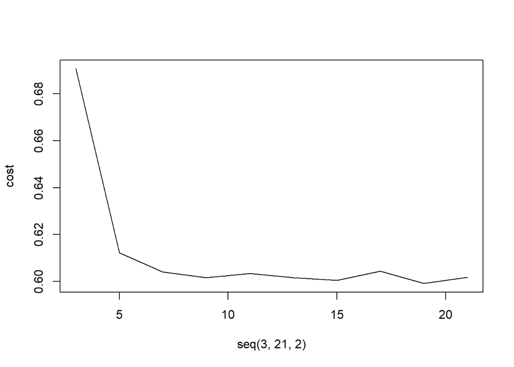

```r
plot(seq(3,21,2), cost, type="l")
```

```r
knn_optimal <- knn(train = train_knn[,-4], test = val[,-c(4,41)], cl = train_knn$y, k = 9)
```

KNN class of models cannot give us any insight into explanatory variables importance/impact with respect to target variable. Also, since there are too many dimensions, it is impossible to see a plot with areas assigning values.